# Similarity between curves

Avan Suinesiaputra

4 March 2016

Let’s say I have three curves like these

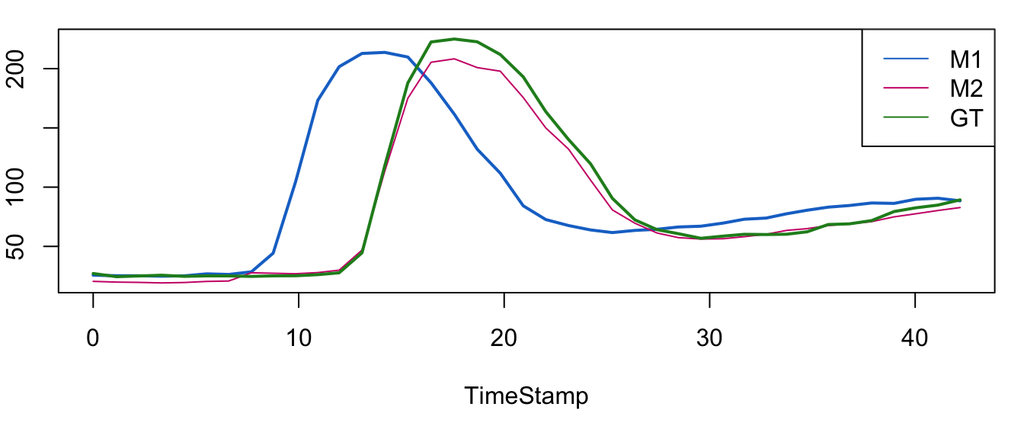

```r
rm(list = ls())
par(mar = c(5, 2, 1, 1))
C = read.csv("./data/curves.csv", header = TRUE)
plot(M1 ~ TimeStamp, data = C, type = "l", col = "dodgerblue3", ylim = range(C[,
    c("M1", "M2", "M3")]), xlab = "TimeStamp", ylab = "", lwd = 2)
lines(M2 ~ TimeStamp, data = C, col = "deeppink3")
lines(M3 ~ TimeStamp, data = C, col = "forestgreen", lwd = 2)
legend("topright", legend = c("M1", "M2", "GT"), col = c("dodgerblue3", "deeppink3",
    "forestgreen"), lty = 1)
```

- *How can I measure the similarity between these curves?*
- *If GT is the ground truth, how close M1 curve compared to M2 curve to the ground truth?*

### Root Mean Squared Deviation (Error)

The easiest way to compare the curves is by computing the **Root Mean Squared Deviation (RMSD)** or also known alse **Root Mean Squared Error (RMSE)**:

$\textrm{RMSE} = \sqrt{\frac{1}{n} \sum_{i=1}^{n}\left(\hat{y}_i - y_i\right)^2}$

```r
rmse = function(y, yi) {
    stopifnot(length(y) == length(yi))
    sqrt(sum((y - yi)^2)/length(y))
}

c(rmse(C$M1, C$M3), rmse(C$M2, C$M3))
```

```
## [1] 61.536253  8.178241
```

### Dynamic Time Warping

**Dynamic Time Warping (DTW)** is a technique to find optimal alignment between two given (time-dependent) sequences, which may vary in speed and time. The technique was first introduced by the speech recognition community, but it has since grown to computer vision, data mining, classification, and other fields that analyse time-series or pseudo time-series data.

Suppose there are two curves $X$ of length $n$ and $Y$ of length $m$ that we want to align: $X = [X_1, X_2, \ldots, X_n] \\ Y = [Y_1, Y_2, \ldots, Y_m]$

In R, there is a package called [`dtw`](http://dtw.r-forge.r-project.org/) that implemented dynamic time warping.

```r
library(dtw)
```

There are two common plots in DTW: alignment and curve-by-curve plots. Let’s make these plots between each curve.

Alignment and curve-by-curve plots between M1 and GT curves:

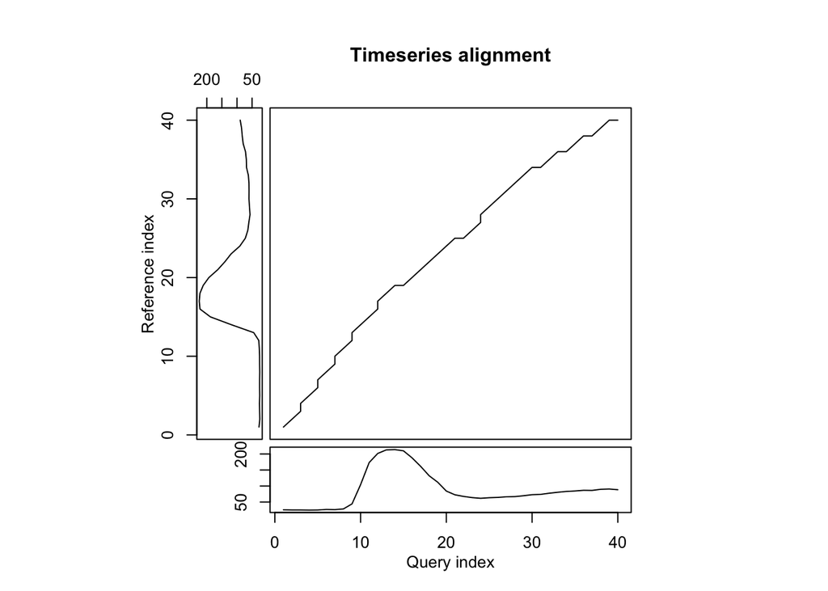

```r
dtw.m1 = dtw(C$M1, C$M3, keep = TRUE, step = rabinerJuangStepPattern(6, "c"))
plot(dtw.m1, type = "threeway")
```

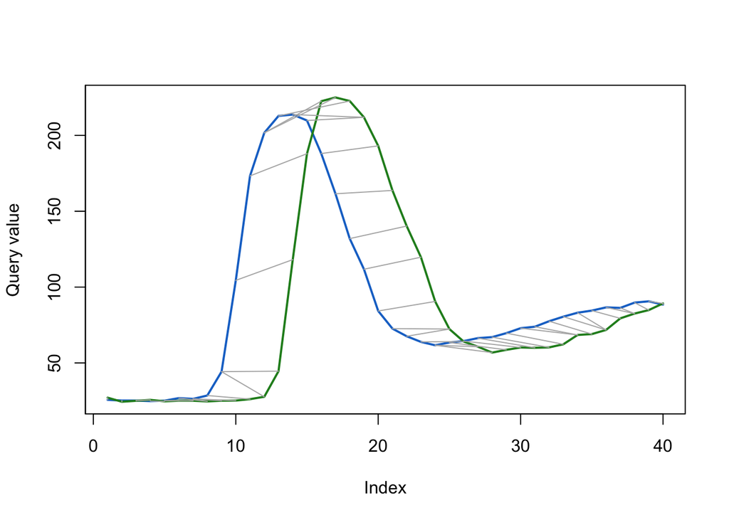

```r
plot(dtw.m1, type = "twoway", match.lty = 1, col = c("dodgerblue3", "forestgreen"),
    lty = 1, lwd = 2)
```

Alignment and curve-by-curve plots between M2 and GT curves:

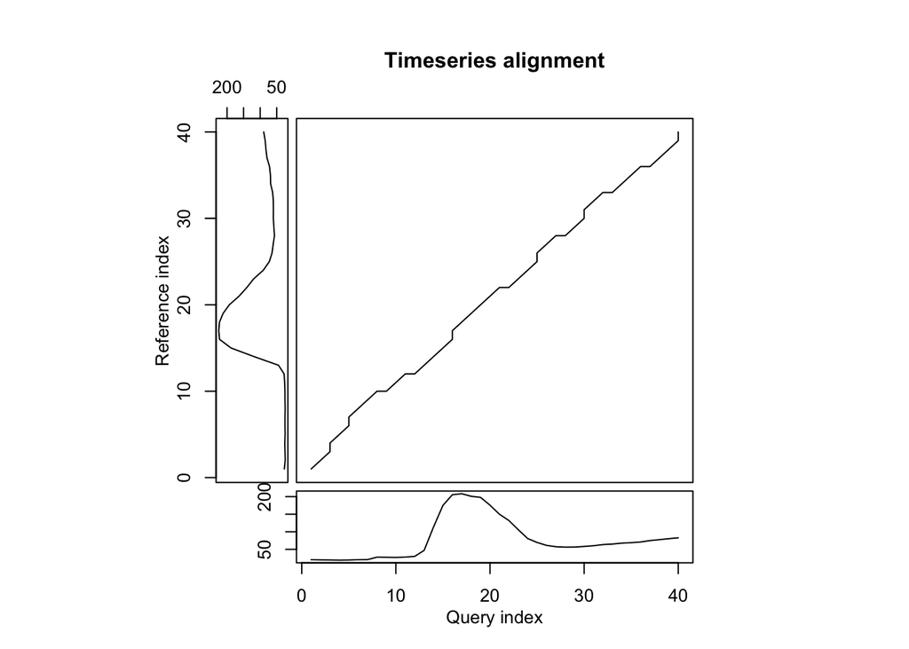

```r
dtw.m2 = dtw(C$M2, C$M3, keep = TRUE, step = rabinerJuangStepPattern(6, "c"))
plot(dtw.m2, type = "threeway")
```

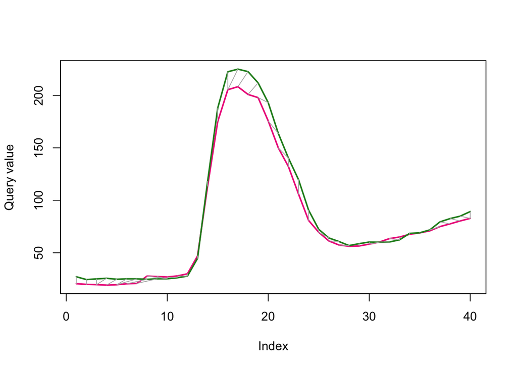

```r
plot(dtw.m2, type = "twoway", match.lty = 1, col = c("deeppink2", "forestgreen"),
    lty = 1, lwd = 2)
```

The normalized distances between M1 to GT and M2 to GT are not that wide anymore:

```r
dtw.m1$normalizedDistance
```

```
## [1] 5.29427
```

```r
dtw.m2$normalizedDistance
```

```
## [1] 4.711373
```